# Analysis of hepatocellular carcinoma data

Normalization with cycloess

Author

Carlota de la Concepción Ruiz

## Contexto

Células de hepatocarcinoma celular se han tratado con 5’-metiltioadenosina (MTA) a diferentes concentraciones y se han tomado muestras a las 24 y a las 48 horas para cada una de las tres réplicas biológicas. Así, tenemos 18 muestras. Se van a comparar las proteínas presentes al mismo tiempo entre diferentes concentraciones para ver con el objetivo de entender a qué rutas metabólicas y funciones afecta la presencia de MTA a diferentes concentraciones.

### Resumen del tratamiento de los datos

El análisis de datos reales, donde no se conoce el resultado final, se ha llevado a cabo de la misma manera. Se han analizado las métricas de PRONE y NAguideR para seleccionar los métodos de normalización e imputación de valores MAR y MNAR. Para estos últimos, como se ha indicado, no sirven las métricas de NAguideR. Sin embargo, como se ha observado, los métodos que peor evaluados aparecen según estas métricas, en el benchmarking realizado anteriormente tienden a ser los óptimos para los valores MNAR.

En cuanto a los métodos de normalización e imputación de valores MAR, se han seleccionado *vsn* y *cycloess* para normalizar los datos. Estos métodos son los que se posicionan como óptimos ya que son los que mejor separan estos grupos de condiciones y más similitudes son capaces de encontrar entre réplicas de un mismo grupo (Tabla suplementaria 3). En cuanto al método de imputación de valores MAR en el caso de la normalización con *cycloess*, se selecciona *bpca* por mostrarse ganador en la mayoría de las réplicas (Tabla suplementaria 4). Finalmente, dado que obtiene la posición más baja según las métricas de NAguideR, se selecciona *halfmin* como método de imputación de valores MNAR.

## Tratamiento de los datos

### Normalización e imputación de valores

Tras la normalización según el método cycloess, se procede a analizar cual es el método de imputación de valores MAR óptimo tras dicha transformación. Para ello, se ejecutan las funciones `im_prepare_se` y `imputation_metrics` indicando el método de normalización utilizado. Tras la verificación manual, se ejecuta la función que devuelve las proteínas diferenciales.

```r
preprocessed_data_MTA <- preprocess_spectronaut("../../../MTA_Report_for_NADIA.tsv",
                                            condition_order = c("h24_0MTA","h24_10MTA", "h24_50MTA", "h48_0MTA","h48_10MTA", "h48_50MTA"),
                                            verbose = FALSE)

# Creating se object for the imputation method analysis
se_imp_MTA_cycloess <- im_prepare_se(preprocessed_data_MTA,
                      norm_method = "cycloess") #Normalization method

imp_metrics_MTA_cycloess<- imputation_metrics(se_imp_MTA_cycloess,
                                assay_name = "cycloess", #Normalization method
                                pattern = "from_data")
```

Table 1: Ranking de métodos de imputación cuando la normalización se lleva a cabo con el métodocycloess.

| **Método** | **NRMSE Rank** | **SOR Rank** | **PSS Rank** | **ACC OI_Rank** | **Rank Mean** |
| --- | --- | --- | --- | --- | --- |
| bpca | 1 | 2 | 2 | 1 | 1.50 |
| missForest | 2 | 4 | 1 | 2 | 2.25 |
| Impseq | 3 | 3 | 4 | 3 | 3.25 |
| Impseqrob | 4 | 1 | 6 | 4 | 3.75 |
| nbavg | 6 | 5 | 3 | 6 | 5.00 |
| mice | 5 | 8 | 7 | 5 | 6.25 |
| knn | 8 | 6 | 5 | 8 | 6.75 |
| limpa | 7 | 7 | 8 | 7 | 7.25 |
| MLE | 9 | 9 | 9 | 9 | 9.00 |
| PI | 10 | 10 | 10 | 12 | 10.50 |
| MinDet | 11 | 11 | 13 | 11 | 11.50 |
| QRILC | 13 | 13 | 11 | 10 | 11.75 |
| MinProb | 12 | 12 | 12 | 13 | 12.25 |
| zero | 14 | 14 | 14 | NA | 14.00 |
| min | 15 | 15 | 15 | NA | 15.00 |
| halfmin | 16 | 16 | 16 | NA | 16.00 |

## Valoración del resultado

### PCA

Mediante el análisis de los componentes principales, se evalua si las muestras se separan de manera correcta en función de las condiciones. Así, se puede visualizar que el primer componente principal separa en función de la hora de la toma de la muestra. El segudo componente separa las muestras en función de la cantidad de droga suministrada.

```r
#Builting scores for PCA graph #FIX porque tengo que hacer scores¿?
scores_PCA_MTA_cycloess <- build_pca_scores(
                            MTA_processed_data_cycloess_lastMNAR$PCA_Input,
                            # To choose the one that i want
                            mode = c("all", "any", "specific"),
                            #   Significance threshold for mode: specific
                            alpha = 0.05,
                            comparison = NULL,
                            subset_label = NULL,
                            # Centering and scaling data before PCA
                            center = TRUE,
                            scale. = TRUE,
                            cond_col = "Condition"
                          )

# Interactive PCA generation
pca_MTA_cycloess <- pca_highchart(
                scores_PCA_MTA_cycloess,
                group_order = c("h24_0MTA","h24_10MTA", "h24_50MTA", "h48_0MTA","h48_10MTA", "h48_50MTA"),
                title = "PCA for MTA samples",
                addEllipses = TRUE,
                ellipse_type = "confidence", #Circular ellipse
                ellipse_level = 0.95, # 95% of confidence of FIX
                show_labels = TRUE,
                label_size = 10
              )

pca_MTA_cycloess #To visualize the PCA
```

[interactive chart not shown]

### Mapa de calor

Al generar el mapa de calor en función de los clusters que aparecen por naturaleza, podemos observar, al igual que en el PCA, si las proteínas de una misma condicion, siguen una misma tendencia.

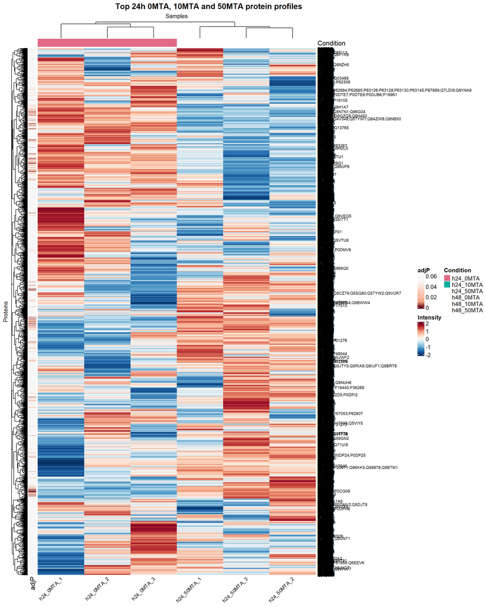

```r
proteomics_heatmap(
  MTA_processed_data_cycloess_lastMNAR$PCA_Input,
  mode = "target",
  comparison = "h24_50MTA - h24_0MTA", #Just colored this comparison, fix
  feature_ids = MTA_processed_data_cycloess_lastMNAR$PCA_Input$FeatureID,
  scale_data = "row",
  sample_order = "clustering", # The samples are distributed due to the clusters formed
  cluster_rows = TRUE, # FALSE
  cluster_columns = TRUE,
  show_row_names = TRUE,
  palette_value = "brewer:RdBu",
  reverse_palette = TRUE,
  heatmap_title = "Top 24h 0MTA, 10MTA and 50MTA protein profiles",
  plot_width = 8,
  plot_height = 7
)
```

### Obtención de proteínas diferenciales

Con el objetivo de visualizar la tendencia de los cambios en cada condición, se han generado los gráficos Volcano. Estos muestran la cantidad de proteínas que se muestras sobreexpresadas así como las infraexpresadas.

#### Volcanos a 24h

```r
volcano_cycloess_24h_10mta <- volcano_highchart_list(
  MTA_processed_data_cycloess_lastMNAR$DEPs_results,
  comparisons = "h24_10MTA - h24_0MTA",
  lfc_thr=0.2,
  show_top_genes = 10, # To highlight the top logFC genes
  title = "10MTA vs 0MTA at 24h"
)

volcano_cycloess_24h_10mta$"h24_10MTA - h24_0MTA"
```

[interactive chart not shown]

```r
volcano_cycloess_24h_50mta <- volcano_highchart_list(
  MTA_processed_data_cycloess_lastMNAR$DEPs_results,
  comparisons = "h24_50MTA - h24_0MTA",
  lfc_thr=0.2,
  show_top_genes = 10, # To highlight the top logFC genes
  title = "50MTA vs 0MTA at 24h"
)

volcano_cycloess_24h_50mta$"h24_50MTA - h24_0MTA"
```

[interactive chart not shown]

#### Volcanos a 48h

```r
volcano_cycloess_48h_10mta <- volcano_highchart_list(
  MTA_processed_data_cycloess_lastMNAR$DEPs_results,
  comparisons = "h48_10MTA - h48_0MTA",
  lfc_thr=0.2,
  show_top_genes = 10, # To highlight the top logFC genes
  title = "10MTA vs 0MTA at 48h"
)

volcano_cycloess_48h_10mta$"h48_10MTA - h48_0MTA"
```

[interactive chart not shown]

```r
volcano_cycloess_48h_50mta <- volcano_highchart_list(
  MTA_processed_data_cycloess_lastMNAR$DEPs_results,
  comparisons = "h48_50MTA - h48_0MTA",
  lfc_thr=0.2,
  show_top_genes = 10, # To highlight the top logFC genes
  title = "50MTA vs 0MTA at 48h"
)

volcano_cycloess_48h_50mta$"h48_50MTA - h48_0MTA"
```

[interactive chart not shown]

### Exporting DEPs

```r
# To select which data I want to download for STRING analysis
results_list_widget(
  MTA_processed_data_cycloess_lastMNAR$DEPs_results, #Diferential expression proteins
  protein_quant = preprocessed_data_MTA$protein_quant) # Raw data with % of appearance
```

Comparison

Change

| Comparison | Protein Groups | Description | Gene Names | Quant Pepts | Change | log₂ FC | P-value | FDR | % Global | % Comp | % Cond 1 | % Cond 2 |
| --- | --- | --- | --- | --- | --- | --- | --- | --- | --- | --- | --- | --- |
| h24_10MTA - h24_0MTA | A0A024RBG1 | Diphosphoinositol polyphosphate phosphohydrolase NUDT4B | NUDT4B | 1 | No Change | 0.00929243253585277 | 0.906987104726707 | 0.983664431280152 | 0 | 0 | 0 | 0 |
| h48_10MTA - h48_0MTA | A0A024RBG1 | Diphosphoinositol polyphosphate phosphohydrolase NUDT4B | NUDT4B | 1 | No Change | -0.0820031283363338 | 0.311275860345089 | 0.733108667520497 | 0 | 0 | 0 | 0 |
| h24_50MTA - h24_0MTA | A0A024RBG1 | Diphosphoinositol polyphosphate phosphohydrolase NUDT4B | NUDT4B | 1 | No Change | -0.238830095743516 | 0.00829681188430217 | 0.0573744296113505 | 0 | 0 | 0 | 0 |
| h48_50MTA - h48_0MTA | A0A024RBG1 | Diphosphoinositol polyphosphate phosphohydrolase NUDT4B | NUDT4B | 1 | Down | -0.275337563119209 | 0.00323612550477172 | 0.0243245417082272 | 0 | 0 | 0 | 0 |
| h24_50MTA - h24_0MTA | A0A096LP01 | Small integral membrane protein 26 | SMIM26 | 1 | No Change | -0.0358074682690432 | 0.772120696131799 | 0.890572795181359 | 0 | 0 | 0 | 0 |
| h48_50MTA - h48_0MTA | A0A096LP01 | Small integral membrane protein 26 | SMIM26 | 1 | No Change | -0.310569004323776 | 0.0222806854834023 | 0.0904810163842192 | 0 | 0 | 0 | 0 |
| h48_10MTA - h48_0MTA | A0A096LP01 | Small integral membrane protein 26 | SMIM26 | 1 | No Change | 0.0927251724551432 | 0.457074865118395 | 0.820549616076558 | 0 | 0 | 0 | 0 |
| h24_10MTA - h24_0MTA | A0A096LP01 | Small integral membrane protein 26 | SMIM26 | 1 | No Change | -0.336496461123931 | 0.0146109164627051 | 0.289603396539874 | 0 | 0 | 0 | 0 |
| h48_50MTA - h48_0MTA | A0A0A0MS06 | Probable non-functional T cell receptor beta variable 23-1 | TRBV23-1 | 1 | No Change | -1.59841000558161 | 0.303639299720115 | 0.512740478053327 | 0 | 0 | 0 | 0 |
| h24_50MTA - h24_0MTA | A0A0A0MS06 | Probable non-functional T cell receptor beta variable 23-1 | TRBV23-1 | 1 | No Change | 0.288525458124607 | 0.849693694454558 | 0.930141099869523 | 0 | 0 | 0 | 0 |

[output cut: 29034 more lines]

### Pattern profiling

```r
pattern_profile_MTA_cycloess_any <- pattern_profiler_analysis(se_proc = MTA_processed_data_cycloess_lastMNAR$se_proc,
                                             DEPs_results = MTA_processed_data_cycloess_lastMNAR$DEPs_results,
                                             assay_name = "bpca_halfmin", # Data to work with
                                             filter_mode = "any", # Diferential on any comparison
                                             #Con todas las comparaciones y any si que funciona
                                             c_range = 2:10)

pp_summary_MTA_cycloess_any <- summarize_pattern_profiler(pattern_profile_MTA_cycloess_any$long_output)

membership_overview <- data.frame(
  Measure = c(
    "Unique proteins",
    "Protein--cluster associations",
    "Proteins associated with multiple clusters"
  ),
  Value = c(
    pp_summary_MTA_cycloess_any$n_unique_features,
    pp_summary_MTA_cycloess_any$n_total_entries,
    pp_summary_MTA_cycloess_any$n_multi_cluster_features
  )
)
```

Table 2: Summary of the soft-clustering assignments.

| Measure | Value |
| --- | --- |
| Unique proteins | 2097 |
| Protein–cluster associations | 2580 |
| Proteins associated with multiple clusters | 483 |

```r
thresholds <- c(0.25, 0.50, 0.70, 0.90)
threshold_table <- data.frame(
  Minimum_membership = thresholds,
  Associations_retained = vapply(
    thresholds,
    function(x) sum(pattern_profile_MTA_cycloess_any$long_output$Membership >= x),
    numeric(1)
  )
)
```

| Minimum_membership | Associations_retained |
| --- | --- |
| 0.25 | 2580 |
| 0.50 | 2097 |
| 0.70 | 1718 |
| 0.90 | 1218 |

#### 24H comparisons

```r
profile_plots_MTA_cycloess_24h<- cluster_profile_highchart_list(
  pattern_profile_MTA_cycloess_any$long_output,
  conditions = c("h24_0MTA","h24_10MTA", "h24_50MTA"),
  min_membership = 0.80, # The protein group should have a 90% of confidence
  centroid_summary = "median"
)

profile_plots_MTA_cycloess_24h
```

[output not shown]

```r
centroid_plot_24h <- cluster_centroids_highchart(
  pattern_profile_MTA_cycloess_any$long_output,
  conditions = c("h24_0MTA", "h24_10MTA", "h24_50MTA"),
  min_membership = 0.70,
  centroid_summary = "median",
  title = "Pattern Profiler cluster centroids"
)

centroid_plot_24h
```

[interactive chart not shown]

#### 48H comparisons

```r
profile_plots_MTA_cycloess_48h<- cluster_profile_highchart_list(
  pattern_profile_MTA_cycloess_any$long_output,
  conditions = c("h48_0MTA","h48_10MTA", "h48_50MTA"),
  min_membership = 0.80,
  centroid_summary = "median"
)

profile_plots_MTA_cycloess_48h
```

[output not shown]

```r
centroid_plot_48h <- cluster_centroids_highchart(
  pattern_profile_MTA_cycloess_any$long_output,
  conditions = c("h48_0MTA", "h48_10MTA", "h48_50MTA"),
  min_membership = 0.70,
  centroid_summary = "median",
  title = "Pattern Profiler cluster centroids"
)

centroid_plot_48h
```

[interactive chart not shown]

#### 24 and 48 H

```r
centroid_plot_any <- cluster_centroids_highchart(
  pattern_profile_MTA_cycloess_any$long_output,
  conditions = pattern_profile_MTA_cycloess_any$conditions,
  min_membership = 0.70,
  centroid_summary = "median",
  title = "Pattern Profiler cluster centroids"
)

centroid_plot_any
```

[interactive chart not shown]

Hay un cluster de proteínas que de manera basal cuenta con poca abundancia. A medida que la concentracion de MTA aumenta, la abundancia también lo hace. Además, este mismo cluster, de manera basal tiene una abundancia mayor que a 24h y de la misma manera, cuando añades MTA, la abundancia de las proteínas de este cluster aumenta.

Esto indica que esas proteínas aumentan sin MTA ya que, a distintos tiempos, sin MTA, la abudancia es superior en el segundo tiempo.

Por otro lado, hay un cluster con la tendencia contraria.